# Final W23 – Solution to 2b

The problem requires the implicit assumption that $\|u\|$ remains fixed as $n \to \infty$, although $u$ has to change (since its dimension is changing). This is not strictly necessary, although it is easier in this case to think about the consistency question, since we are estimating a fixed parameter.

1. **Reparametrizing MLE**: The likelihood is proportional to
   $$\begin{align*}
   \ell(u) &\propto_u \frac12 e^{-\frac12\|y - u\|^2} + \frac12 e^{-\frac12 \|y+u\|^2} \\
   &\propto_u e^{-\frac12 \|u\|^2} \cosh(\langle y,u\rangle)
   \end{align*}$$
   Let us parameterize in terms of $\alpha = \|u\| \in [0,\infty)$ and $\omega = u / \|u\| \in \mathbb R^n$ (for $\alpha = 0$, we can define $\omega$ arbitrarily). We have $u = \alpha \omega$. Then,
   $$\begin{align*}
   \ell(\alpha, \omega) \propto e^{-\frac12 \alpha^2} \cosh(\alpha \langle y,\omega\rangle).
   \end{align*}$$
   To obtain the MLE of $(\alpha,\omega)$, we need to maximize the above function over both arguments. We first maximize over $\omega$, and then maximize over $\alpha$. When we maximize over $\omega$ the solution potentially depends on $\alpha$, but in this particular case, the maximizer over $\omega$ is independent of $\alpha$, hence it actually gives us the MLE of $\omega$ directly.
2. **MLE of $\omega$**: Maximizing over $\omega$—by Cauchy-Schwarz and since $\cosh$ is increasing on $[0, \infty)$—we obtain $\widehat{\omega} = \pm y / \|y\|$. Note that the solution does not depend on $\alpha$, hence $\widehat \omega$ is the MLE of $\omega$. Both $\pm$ give the same value of the likelihood, hence both can be used as the MLE, that is, the MLE of $\omega$ is not unique, going back to nonidentifiability.
3. **MLE of $\alpha$**: Plugging in $\widehat\omega$ into the $\ell(\alpha, \omega)$, we have (note that $\cosh(t) = \cosh(-t)$ for all $t$)
   $$\begin{align*}
   \ell(\alpha, \widehat\omega) \propto_\alpha e^{-\frac12 \alpha^2} \cosh(\alpha\|y\|).
   \end{align*}$$
   To obtain the MLE of $\alpha$, we need to maximize the above over $\alpha$. Maximizing over $\alpha$, we need to understand the behavior of
   $$f(t;a) = e^{-t^2/2} \cosh(a t).$$
   We have $f'(t;a) = e^{-t^2/2}(a \sinh(at) - t \cosh(at))$. The critical points are then the solution of
   $$\tanh(at) = t/a.$$
   Zero is always a solution. If $a \le 1$, zero is the only solution and then it is easy to verify that it is the unique maximum of the function. This means that when $\|y\| < 1$, the MLE for $\alpha$ is zero. The following plot illustrates the situation:

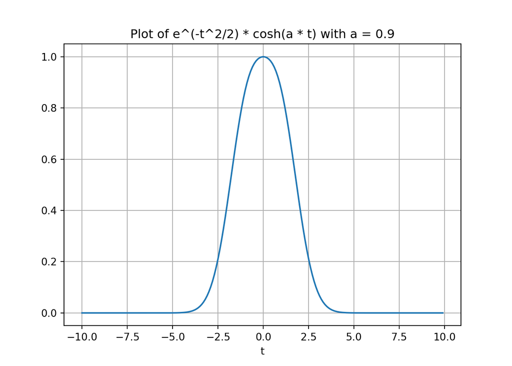

   If $a > 1$, then there are also two nonzero solutions, symmetrically positioned around zero. Let us denote them as $\pm M(a)$ where $M(a) > 0$. The maximum occurs at these two points, $t = \pm M(a)$, and the critical point $t=0$ corresponds to a minimum in this case. This means that when $\|y\| > 1$, the MLE for $\alpha$ is $M(\|y\|)$ (since $\alpha \ge 0$ by definition). The following plot illustrates the situation:

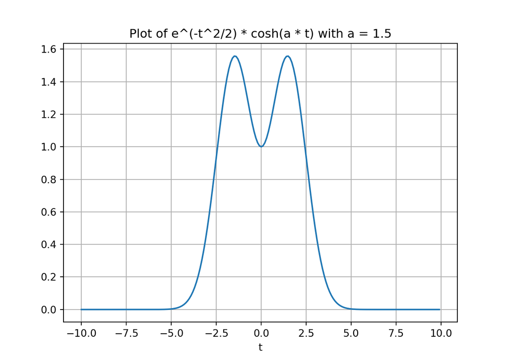

   Thus, the MLE for $\alpha$ is
   $$\begin{align*}
   \widehat \alpha =
   \begin{cases}
   0 & \|y\| \le 1, \\
   M(\|y\|) & \|y\| > 1.
   \end{cases} %= g(\norm{y}), \quad g(a) = M(a) 1\{a > 1\}.
   \end{align*}$$
   We also note that $M(a)/a \to 1$ as $a \to \infty$. (Needs checking.)
4. **Asymptotic behavior of $\|y\|$**. Recall that $\alpha = \|u\|$ is the parameter of interest and the MLE for it, given above, is a function of $\|y\|$. So we need to study the behavior of $\|y\|$ as $n \to \infty$. Recall that
   $$y = \theta u + z = \theta \alpha \omega + z$$
   where $z \sim N(0,I_n)$. The short argument is that the norm of $z$ is of the order of $\sqrt n$ asymptotiically, while the norm of the first term is $\|\theta \alpha \omega\| =|\theta| \alpha \|\omega\| = \alpha$. Since $\alpha$ is constant and $\sqrt{n} \to \infty$, the norm of $y$ is dominated by the norm of $z$ and has no information asymptotically about $\alpha$. This shows that $\widehat \alpha$ is **inconsistent** for $\alpha$.
5. A bit more precisely,
   $$\begin{align*}
   R_n^2 := \frac{\|y\|^2}n = \frac{\alpha^2}n + \frac{\|z\|^2}n + 2 \alpha \frac{\theta\langle\omega,z\rangle}n.
   \end{align*}$$
   Note that $\alpha$ is constant. The first term is $o(1)$. By the LLN, we have $\frac1n \|z\|^2 = 1 + o_p(1)$. Since $\theta\langle\omega, z\rangle \sim N(0,1)$, we have $\theta\langle\omega,z\rangle = O_p(1)$, hence the third term is $o_p(1)$. Putting the pieces together,
   $$\begin{align*}
   R_n^2 = 1 + o_p(1).
   \end{align*}$$
   That is, $\|y\| = \sqrt n R_n = \sqrt{n}(1+o_p(1))$. With high probability as $n \to \infty$, we have $\|y\| > 1$, hence $\widehat \alpha = M(\|y\|) \sim M(\sqrt n) \sim \sqrt{n}$, that is, $\widehat \alpha$ goes to infinity and hence inconsistent for $\alpha$.